# Introduction to R Markdown

Nathan Vandeweerd

2021-03-16

# Abstract

R Markdown (Allaire et al., 2020; Xie, Allaire, & Grolemund, 2018; Xie, Dervieux, & Riederer, 2020) is a suite of tools that allow you to seamlessly integrate text and R code together to create fully reproducible documents. From one R Markdown file, you can easily create various output files including Word documents, Powerpoints, conference posters and [much more](https://rmarkdown.rstudio.com/)! This introductory workshop will go over the basics of R Markdown and demonstrate how it can be used to support reproducible research. A basic knowledge of R is assumed but no prior knowledge of R Markdown is required.

> R Markdown was designed for easier reproducibility, since both the computing code and narratives are in the same document, and results are automatically generated from the source code. R Markdown supports dozens of static and dynamic/interactive output formats.

## Topics covered:

- Introduction to R Markdown
- Integrating R code in your R Markdown document
- Inserting graphics and tables
- Adding a bibliography

# Integrating R code

Code chunks:

```r
1+1
```

```
## [1] 2
```

Inline code:

The sum of 1 + 1 is 2.

# Inserting graphics

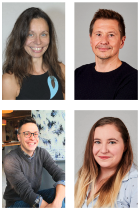

Project Members

```r
knitr::include_graphics("project_members.png")
```

# Note: file management

The default working directory is the folder where the .Rmd file is located. In order to stay organized, it’s good to work in “projects.” Each project gets its own folder with sub-folders for data, reports, presentations etc. When working in projects, a very handy package is the **here** package which creates file paths relative to the project directory.

```r
library(here)
here()
```

```
## [1] "/Users/nvandew/OneDrive - UCL/Research/Projects/mkdn_workshop"
```

```r
here("data")
```

```
## [1] "/Users/nvandew/OneDrive - UCL/Research/Projects/mkdn_workshop/data"
```

# Inserting tables

The `lsnp.info.csv` file is located in the `data/` folder. I used **here()** to build a path there.

Text lengths by task

| TASK | min | median | mean | max |
| --- | --- | --- | --- | --- |
| lgbt_essay | 110 | 213.0 | 212.72 | 306 |
| drugs_essay | 143 | 209.5 | 208.00 | 279 |
| food_essay | 155 | 212.0 | 209.91 | 298 |
| cat_story | 130 | 335.0 | 349.72 | 842 |
| sisters_story | 211 | 402.5 | 410.27 | 916 |
| brothers_story | 123 | 265.0 | 297.17 | 778 |
| interview | 282 | 1021.0 | 1231.45 | 4158 |

# Inserting plots

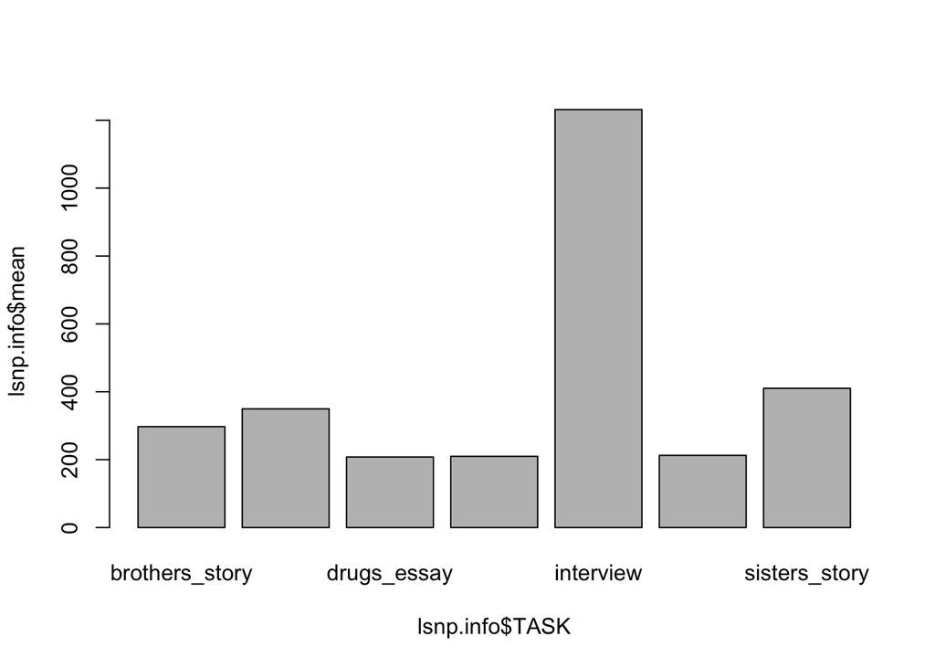

# References

Allaire, J. J., Xie, Y., McPherson, J., Luraschi, J., Ushey, K., Atkins, A., … Iannone, R. (2020). *rmarkdown: Dynamic Documents for R*. Retrieved from https://github.com/rstudio/rmarkdown

Xie, Y., Allaire, J. J., & Grolemund, G. (2018). *R Markdown: The Definitive Guide*. Retrieved from https://bookdown.org/yihui/rmarkdown

Xie, Y., Dervieux, C., & Riederer, E. (2020). *R Markdown Cookbook*. Retrieved from https://bookdown.org/yihui/rmarkdown-cookbook